# Risk Factor Analysis

## Outcome Variable

**Outcome Variable:** haz

## Predictor Variables

**Intervention Variable:** nhh

**Adjustment Set:**

- arm
- W_mage
- meducyrs
- feducyrs
- hhwealth_quart
- W_mhtcm
- W_mwtkg
- W_mbmi
- W_nrooms
- cleanck
- impfloor
- impsan
- safeh20
- delta_W_mage
- delta_meducyrs
- delta_feducyrs
- delta_hhwealth_quart
- delta_W_mhtcm
- delta_W_mwtkg
- delta_W_mbmi
- delta_W_nrooms
- delta_cleanck
- delta_impfloor
- delta_impsan
- delta_safeh20

## Stratifying Variables

The analysis was stratified on these variable(s):

- agecat
- studyid
- country

## Data Summary

| agecat | studyid | country | nhh | n_cell | n |
| --- | --- | --- | --- | --- | --- |
| Birth | ki1000108-IRC | INDIA | 3 or less | 54 | 388 |
| Birth | ki1000108-IRC | INDIA | 4-5 | 150 | 388 |
| Birth | ki1000108-IRC | INDIA | 6-7 | 103 | 388 |
| Birth | ki1000108-IRC | INDIA | 8+ | 81 | 388 |
| Birth | ki1017093-NIH-Birth | BANGLADESH | 3 or less | 7 | 28 |
| Birth | ki1017093-NIH-Birth | BANGLADESH | 4-5 | 11 | 28 |
| Birth | ki1017093-NIH-Birth | BANGLADESH | 6-7 | 7 | 28 |
| Birth | ki1017093-NIH-Birth | BANGLADESH | 8+ | 3 | 28 |
| Birth | ki1017093c-NIH-Crypto | BANGLADESH | 3 or less | 8 | 27 |
| Birth | ki1017093c-NIH-Crypto | BANGLADESH | 4-5 | 9 | 27 |
| Birth | ki1017093c-NIH-Crypto | BANGLADESH | 6-7 | 7 | 27 |
| Birth | ki1017093c-NIH-Crypto | BANGLADESH | 8+ | 3 | 27 |
| 6 months | ki1000108-IRC | INDIA | 3 or less | 58 | 407 |
| 6 months | ki1000108-IRC | INDIA | 4-5 | 158 | 407 |
| 6 months | ki1000108-IRC | INDIA | 6-7 | 106 | 407 |
| 6 months | ki1000108-IRC | INDIA | 8+ | 85 | 407 |
| 6 months | ki1000304b-SAS-FoodSuppl | INDIA | 3 or less | 33 | 380 |
| 6 months | ki1000304b-SAS-FoodSuppl | INDIA | 4-5 | 166 | 380 |
| 6 months | ki1000304b-SAS-FoodSuppl | INDIA | 6-7 | 115 | 380 |
| 6 months | ki1000304b-SAS-FoodSuppl | INDIA | 8+ | 66 | 380 |
| 6 months | ki1017093-NIH-Birth | BANGLADESH | 3 or less | 95 | 537 |
| 6 months | ki1017093-NIH-Birth | BANGLADESH | 4-5 | 227 | 537 |
| 6 months | ki1017093-NIH-Birth | BANGLADESH | 6-7 | 128 | 537 |
| 6 months | ki1017093-NIH-Birth | BANGLADESH | 8+ | 87 | 537 |
| 6 months | ki1017093b-PROVIDE | BANGLADESH | 3 or less | 102 | 583 |
| 6 months | ki1017093b-PROVIDE | BANGLADESH | 4-5 | 277 | 583 |
| 6 months | ki1017093b-PROVIDE | BANGLADESH | 6-7 | 126 | 583 |
| 6 months | ki1017093b-PROVIDE | BANGLADESH | 8+ | 78 | 583 |
| 6 months | ki1017093c-NIH-Crypto | BANGLADESH | 3 or less | 104 | 715 |
| 6 months | ki1017093c-NIH-Crypto | BANGLADESH | 4-5 | 326 | 715 |
| 6 months | ki1017093c-NIH-Crypto | BANGLADESH | 6-7 | 170 | 715 |
| 6 months | ki1017093c-NIH-Crypto | BANGLADESH | 8+ | 115 | 715 |
| 6 months | ki1148112-LCNI-5 | MALAWI | 3 or less | 224 | 816 |
| 6 months | ki1148112-LCNI-5 | MALAWI | 4-5 | 340 | 816 |
| 6 months | ki1148112-LCNI-5 | MALAWI | 6-7 | 182 | 816 |
| 6 months | ki1148112-LCNI-5 | MALAWI | 8+ | 70 | 816 |
| 24 months | ki1000108-IRC | INDIA | 3 or less | 58 | 409 |
| 24 months | ki1000108-IRC | INDIA | 4-5 | 158 | 409 |
| 24 months | ki1000108-IRC | INDIA | 6-7 | 107 | 409 |
| 24 months | ki1000108-IRC | INDIA | 8+ | 86 | 409 |
| 24 months | ki1017093-NIH-Birth | BANGLADESH | 3 or less | 75 | 429 |
| 24 months | ki1017093-NIH-Birth | BANGLADESH | 4-5 | 184 | 429 |
| 24 months | ki1017093-NIH-Birth | BANGLADESH | 6-7 | 100 | 429 |
| 24 months | ki1017093-NIH-Birth | BANGLADESH | 8+ | 70 | 429 |
| 24 months | ki1017093b-PROVIDE | BANGLADESH | 3 or less | 105 | 577 |
| 24 months | ki1017093b-PROVIDE | BANGLADESH | 4-5 | 273 | 577 |
| 24 months | ki1017093b-PROVIDE | BANGLADESH | 6-7 | 117 | 577 |
| 24 months | ki1017093b-PROVIDE | BANGLADESH | 8+ | 82 | 577 |
| 24 months | ki1017093c-NIH-Crypto | BANGLADESH | 3 or less | 69 | 514 |
| 24 months | ki1017093c-NIH-Crypto | BANGLADESH | 4-5 | 232 | 514 |
| 24 months | ki1017093c-NIH-Crypto | BANGLADESH | 6-7 | 130 | 514 |
| 24 months | ki1017093c-NIH-Crypto | BANGLADESH | 8+ | 83 | 514 |
| 24 months | ki1148112-LCNI-5 | MALAWI | 3 or less | 159 | 574 |
| 24 months | ki1148112-LCNI-5 | MALAWI | 4-5 | 237 | 574 |
| 24 months | ki1148112-LCNI-5 | MALAWI | 6-7 | 129 | 574 |
| 24 months | ki1148112-LCNI-5 | MALAWI | 8+ | 49 | 574 |

The following strata were considered:

- agecat: 24 months, studyid: ki1000108-IRC, country: INDIA
- agecat: 24 months, studyid: ki1017093-NIH-Birth, country: BANGLADESH
- agecat: 24 months, studyid: ki1017093b-PROVIDE, country: BANGLADESH
- agecat: 24 months, studyid: ki1017093c-NIH-Crypto, country: BANGLADESH
- agecat: 24 months, studyid: ki1148112-LCNI-5, country: MALAWI
- agecat: 6 months, studyid: ki1000108-IRC, country: INDIA
- agecat: 6 months, studyid: ki1000304b-SAS-FoodSuppl, country: INDIA
- agecat: 6 months, studyid: ki1017093-NIH-Birth, country: BANGLADESH
- agecat: 6 months, studyid: ki1017093b-PROVIDE, country: BANGLADESH
- agecat: 6 months, studyid: ki1017093c-NIH-Crypto, country: BANGLADESH
- agecat: 6 months, studyid: ki1148112-LCNI-5, country: MALAWI
- agecat: Birth, studyid: ki1000108-IRC, country: INDIA
- agecat: Birth, studyid: ki1017093-NIH-Birth, country: BANGLADESH
- agecat: Birth, studyid: ki1017093c-NIH-Crypto, country: BANGLADESH

### Dropped Strata

Some strata were dropped due to rare outcomes:

- agecat: Birth, studyid: ki1017093-NIH-Birth, country: BANGLADESH
- agecat: Birth, studyid: ki1017093c-NIH-Crypto, country: BANGLADESH

## Methods Detail

We’re interested in the causal parameters $E[Y_a]$ for all values of $a \in \mathcal{A}$. These parameters represent the mean outcome if, possibly contrary to fact, we intervened to set all units to have $A=a$. Under the randomization and positivity assumptions, these are identified by the statistical parameters $\psi_a=E_W[E_{Y|A,W}(Y|A=a,W)]$. In addition, we’re interested in the mean of $Y$, $E[Y]$ under no intervention (the observed mean). We will estimate these parameters by using SuperLearner to fit the relevant likelihood factors – $E_{Y|A,W}(Y|A=a,W)$ and $p(A=a|W)$, and then updating our likelihood fit using a joint TMLE.

For unadjusted analyses ($W=\{\}$), initial likelihoods were estimated using Lrnr_glm to estimate the simple $E(Y|A)$ and Lrnr_mean to estimate $p(A)$. For adjusted analyses, a small library containing Lrnr_glmnet, Lrnr_xgboost, and Lrnr_mean was used.

Having estimated these parameters, we will then use the delta method to estimate relative risks and attributable risks relative to a prespecified baseline level of $A$.

# Results Detail

## Results Plots

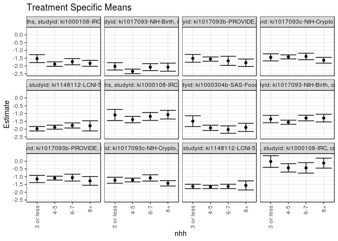

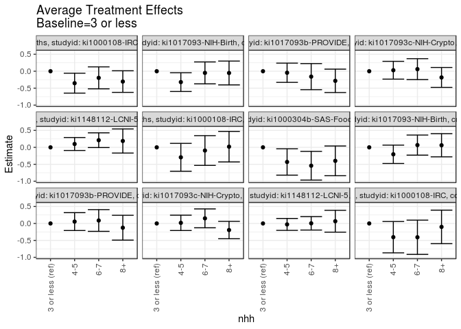

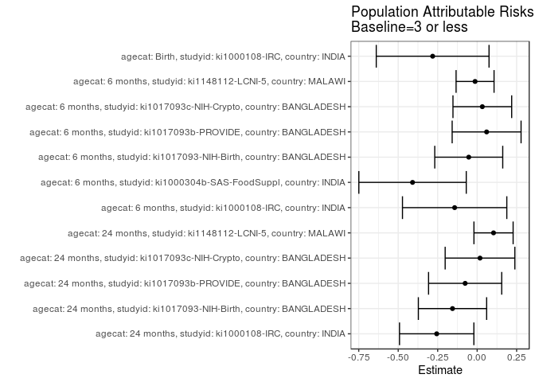

## Results Table

### Parameter: TSM

| agecat | studyid | country | intervention_level | baseline_level | estimate | ci_lower | ci_upper |
| --- | --- | --- | --- | --- | --- | --- | --- |
| Birth | ki1000108-IRC | INDIA | 3 or less | NA | -0.0261894 | -0.4008505 | 0.3484717 |
| Birth | ki1000108-IRC | INDIA | 4-5 | NA | -0.4308838 | -0.7010805 | -0.1606870 |
| Birth | ki1000108-IRC | INDIA | 6-7 | NA | -0.4334230 | -0.7708700 | -0.0959760 |
| Birth | ki1000108-IRC | INDIA | 8+ | NA | -0.1276978 | -0.4475248 | 0.1921292 |
| 6 months | ki1000108-IRC | INDIA | 3 or less | NA | -1.0918055 | -1.4508429 | -0.7327682 |
| 6 months | ki1000108-IRC | INDIA | 4-5 | NA | -1.3860701 | -1.5928259 | -1.1793143 |
| 6 months | ki1000108-IRC | INDIA | 6-7 | NA | -1.1856926 | -1.4372502 | -0.9341350 |
| 6 months | ki1000108-IRC | INDIA | 8+ | NA | -1.0721735 | -1.3511421 | -0.7932048 |
| 6 months | ki1000304b-SAS-FoodSuppl | INDIA | 3 or less | NA | -1.4894974 | -1.8394261 | -1.1395686 |
| 6 months | ki1000304b-SAS-FoodSuppl | INDIA | 4-5 | NA | -1.9205215 | -2.0905070 | -1.7505360 |
| 6 months | ki1000304b-SAS-FoodSuppl | INDIA | 6-7 | NA | -2.0312187 | -2.2697366 | -1.7927009 |
| 6 months | ki1000304b-SAS-FoodSuppl | INDIA | 8+ | NA | -1.8885357 | -2.1523271 | -1.6247442 |
| 6 months | ki1017093-NIH-Birth | BANGLADESH | 3 or less | NA | -1.3541230 | -1.5916181 | -1.1166279 |
| 6 months | ki1017093-NIH-Birth | BANGLADESH | 4-5 | NA | -1.5591504 | -1.6916556 | -1.4266452 |
| 6 months | ki1017093-NIH-Birth | BANGLADESH | 6-7 | NA | -1.2877921 | -1.4668971 | -1.1086871 |
| 6 months | ki1017093-NIH-Birth | BANGLADESH | 8+ | NA | -1.2927908 | -1.5403108 | -1.0452709 |
| 6 months | ki1017093b-PROVIDE | BANGLADESH | 3 or less | NA | -1.1470329 | -1.3787786 | -0.9152873 |
| 6 months | ki1017093b-PROVIDE | BANGLADESH | 4-5 | NA | -1.0919585 | -1.2168542 | -0.9670628 |
| 6 months | ki1017093b-PROVIDE | BANGLADESH | 6-7 | NA | -1.0596626 | -1.2804499 | -0.8388753 |
| 6 months | ki1017093b-PROVIDE | BANGLADESH | 8+ | NA | -1.2727396 | -1.5561300 | -0.9893493 |
| 6 months | ki1017093c-NIH-Crypto | BANGLADESH | 3 or less | NA | -1.2314127 | -1.4229065 | -1.0399190 |
| 6 months | ki1017093c-NIH-Crypto | BANGLADESH | 4-5 | NA | -1.2136232 | -1.3361859 | -1.0910605 |
| 6 months | ki1017093c-NIH-Crypto | BANGLADESH | 6-7 | NA | -1.0807093 | -1.2837544 | -0.8776642 |
| 6 months | ki1017093c-NIH-Crypto | BANGLADESH | 8+ | NA | -1.4261369 | -1.5989832 | -1.2532906 |
| 6 months | ki1148112-LCNI-5 | MALAWI | 3 or less | NA | -1.6294699 | -1.7711277 | -1.4878122 |
| 6 months | ki1148112-LCNI-5 | MALAWI | 4-5 | NA | -1.6577940 | -1.7645947 | -1.5509934 |
| 6 months | ki1148112-LCNI-5 | MALAWI | 6-7 | NA | -1.6255479 | -1.7669687 | -1.4841271 |
| 6 months | ki1148112-LCNI-5 | MALAWI | 8+ | NA | -1.5637758 | -1.8551074 | -1.2724441 |
| 24 months | ki1000108-IRC | INDIA | 3 or less | NA | -1.5262229 | -1.7817671 | -1.2706787 |
| 24 months | ki1000108-IRC | INDIA | 4-5 | NA | -1.8792512 | -2.0252745 | -1.7332280 |
| 24 months | ki1000108-IRC | INDIA | 6-7 | NA | -1.7217659 | -1.9214058 | -1.5221261 |
| 24 months | ki1000108-IRC | INDIA | 8+ | NA | -1.8311152 | -2.0220942 | -1.6401363 |
| 24 months | ki1017093-NIH-Birth | BANGLADESH | 3 or less | NA | -2.0246626 | -2.2615115 | -1.7878137 |
| 24 months | ki1017093-NIH-Birth | BANGLADESH | 4-5 | NA | -2.3456265 | -2.4914658 | -2.1997872 |
| 24 months | ki1017093-NIH-Birth | BANGLADESH | 6-7 | NA | -2.0741275 | -2.2970348 | -1.8512202 |
| 24 months | ki1017093-NIH-Birth | BANGLADESH | 8+ | NA | -2.0767413 | -2.3385841 | -1.8148985 |
| 24 months | ki1017093b-PROVIDE | BANGLADESH | 3 or less | NA | -1.5100214 | -1.7596335 | -1.2604093 |
| 24 months | ki1017093b-PROVIDE | BANGLADESH | 4-5 | NA | -1.5547723 | -1.6899494 | -1.4195952 |
| 24 months | ki1017093b-PROVIDE | BANGLADESH | 6-7 | NA | -1.6695849 | -1.9626996 | -1.3764702 |
| 24 months | ki1017093b-PROVIDE | BANGLADESH | 8+ | NA | -1.7939670 | -2.0332010 | -1.5547331 |
| 24 months | ki1017093c-NIH-Crypto | BANGLADESH | 3 or less | NA | -1.4476149 | -1.6753067 | -1.2199230 |
| 24 months | ki1017093c-NIH-Crypto | BANGLADESH | 4-5 | NA | -1.4183534 | -1.5484301 | -1.2882766 |
| 24 months | ki1017093c-NIH-Crypto | BANGLADESH | 6-7 | NA | -1.3863811 | -1.5947429 | -1.1780193 |
| 24 months | ki1017093c-NIH-Crypto | BANGLADESH | 8+ | NA | -1.6314357 | -1.8171391 | -1.4457323 |
| 24 months | ki1148112-LCNI-5 | MALAWI | 3 or less | NA | -1.9752201 | -2.1185448 | -1.8318953 |
| 24 months | ki1148112-LCNI-5 | MALAWI | 4-5 | NA | -1.8768860 | -2.0058293 | -1.7479428 |
| 24 months | ki1148112-LCNI-5 | MALAWI | 6-7 | NA | -1.7646899 | -1.9290722 | -1.6003076 |
| 24 months | ki1148112-LCNI-5 | MALAWI | 8+ | NA | -1.7877089 | -2.1149049 | -1.4605129 |

### Parameter: E(Y)

| agecat | studyid | country | intervention_level | baseline_level | estimate | ci_lower | ci_upper |
| --- | --- | --- | --- | --- | --- | --- | --- |
| Birth | ki1000108-IRC | INDIA | NA | NA | -0.3080412 | -0.4687931 | -0.1472894 |
| 6 months | ki1000108-IRC | INDIA | NA | NA | -1.2344062 | -1.3658524 | -1.1029600 |
| 6 months | ki1000304b-SAS-FoodSuppl | INDIA | NA | NA | -1.8986842 | -2.0118892 | -1.7854792 |
| 6 months | ki1017093-NIH-Birth | BANGLADESH | NA | NA | -1.4073821 | -1.4960598 | -1.3187043 |
| 6 months | ki1017093b-PROVIDE | BANGLADESH | NA | NA | -1.0871041 | -1.1635539 | -1.0106543 |
| 6 months | ki1017093c-NIH-Crypto | BANGLADESH | NA | NA | -1.1986783 | -1.2700937 | -1.1272630 |
| 6 months | ki1148112-LCNI-5 | MALAWI | NA | NA | -1.6426961 | -1.7120603 | -1.5733318 |
| 24 months | ki1000108-IRC | INDIA | NA | NA | -1.7824776 | -1.8765600 | -1.6883952 |
| 24 months | ki1017093-NIH-Birth | BANGLADESH | NA | NA | -2.1807945 | -2.2835902 | -2.0779987 |
| 24 months | ki1017093b-PROVIDE | BANGLADESH | NA | NA | -1.5861179 | -1.6693668 | -1.5028689 |
| 24 months | ki1017093c-NIH-Crypto | BANGLADESH | NA | NA | -1.4295331 | -1.5127726 | -1.3462935 |
| 24 months | ki1148112-LCNI-5 | MALAWI | NA | NA | -1.8714634 | -1.9528558 | -1.7900711 |

### Parameter: ATE

| agecat | studyid | country | intervention_level | baseline_level | estimate | ci_lower | ci_upper |
| --- | --- | --- | --- | --- | --- | --- | --- |
| Birth | ki1000108-IRC | INDIA | 3 or less | 3 or less | 0.0000000 | 0.0000000 | 0.0000000 |
| Birth | ki1000108-IRC | INDIA | 4-5 | 3 or less | -0.4046944 | -0.8673541 | 0.0579653 |
| Birth | ki1000108-IRC | INDIA | 6-7 | 3 or less | -0.4072336 | -0.9123962 | 0.0979290 |
| Birth | ki1000108-IRC | INDIA | 8+ | 3 or less | -0.1015084 | -0.5955801 | 0.3925633 |
| 6 months | ki1000108-IRC | INDIA | 3 or less | 3 or less | 0.0000000 | 0.0000000 | 0.0000000 |
| 6 months | ki1000108-IRC | INDIA | 4-5 | 3 or less | -0.2942646 | -0.7060078 | 0.1174787 |
| 6 months | ki1000108-IRC | INDIA | 6-7 | 3 or less | -0.0938871 | -0.5323710 | 0.3445968 |
| 6 months | ki1000108-IRC | INDIA | 8+ | 3 or less | 0.0196320 | -0.4310970 | 0.4703611 |
| 6 months | ki1000304b-SAS-FoodSuppl | INDIA | 3 or less | 3 or less | 0.0000000 | 0.0000000 | 0.0000000 |
| 6 months | ki1000304b-SAS-FoodSuppl | INDIA | 4-5 | 3 or less | -0.4310241 | -0.8203210 | -0.0417273 |
| 6 months | ki1000304b-SAS-FoodSuppl | INDIA | 6-7 | 3 or less | -0.5417214 | -0.9650859 | -0.1183569 |
| 6 months | ki1000304b-SAS-FoodSuppl | INDIA | 8+ | 3 or less | -0.3990383 | -0.8375590 | 0.0394824 |
| 6 months | ki1017093-NIH-Birth | BANGLADESH | 3 or less | 3 or less | 0.0000000 | 0.0000000 | 0.0000000 |
| 6 months | ki1017093-NIH-Birth | BANGLADESH | 4-5 | 3 or less | -0.2050274 | -0.4763108 | 0.0662561 |
| 6 months | ki1017093-NIH-Birth | BANGLADESH | 6-7 | 3 or less | 0.0663309 | -0.2298758 | 0.3625376 |
| 6 months | ki1017093-NIH-Birth | BANGLADESH | 8+ | 3 or less | 0.0613322 | -0.2807642 | 0.4034286 |
| 6 months | ki1017093b-PROVIDE | BANGLADESH | 3 or less | 3 or less | 0.0000000 | 0.0000000 | 0.0000000 |
| 6 months | ki1017093b-PROVIDE | BANGLADESH | 4-5 | 3 or less | 0.0550744 | -0.2083758 | 0.3185246 |
| 6 months | ki1017093b-PROVIDE | BANGLADESH | 6-7 | 3 or less | 0.0873703 | -0.2328858 | 0.4076265 |
| 6 months | ki1017093b-PROVIDE | BANGLADESH | 8+ | 3 or less | -0.1257067 | -0.4918425 | 0.2404291 |
| 6 months | ki1017093c-NIH-Crypto | BANGLADESH | 3 or less | 3 or less | 0.0000000 | 0.0000000 | 0.0000000 |
| 6 months | ki1017093c-NIH-Crypto | BANGLADESH | 4-5 | 3 or less | 0.0177895 | -0.2084421 | 0.2440211 |
| 6 months | ki1017093c-NIH-Crypto | BANGLADESH | 6-7 | 3 or less | 0.1507034 | -0.1276398 | 0.4290466 |
| 6 months | ki1017093c-NIH-Crypto | BANGLADESH | 8+ | 3 or less | -0.1947242 | -0.4510104 | 0.0615621 |
| 6 months | ki1148112-LCNI-5 | MALAWI | 3 or less | 3 or less | 0.0000000 | 0.0000000 | 0.0000000 |
| 6 months | ki1148112-LCNI-5 | MALAWI | 4-5 | 3 or less | -0.0283241 | -0.2040290 | 0.1473808 |
| 6 months | ki1148112-LCNI-5 | MALAWI | 6-7 | 3 or less | 0.0039220 | -0.1945169 | 0.2023609 |
| 6 months | ki1148112-LCNI-5 | MALAWI | 8+ | 3 or less | 0.0656941 | -0.2562430 | 0.3876313 |
| 24 months | ki1000108-IRC | INDIA | 3 or less | 3 or less | 0.0000000 | 0.0000000 | 0.0000000 |
| 24 months | ki1000108-IRC | INDIA | 4-5 | 3 or less | -0.3530284 | -0.6470877 | -0.0589690 |
| 24 months | ki1000108-IRC | INDIA | 6-7 | 3 or less | -0.1955431 | -0.5196097 | 0.1285236 |
| 24 months | ki1000108-IRC | INDIA | 8+ | 3 or less | -0.3048924 | -0.6236341 | 0.0138493 |
| 24 months | ki1017093-NIH-Birth | BANGLADESH | 3 or less | 3 or less | 0.0000000 | 0.0000000 | 0.0000000 |
| 24 months | ki1017093-NIH-Birth | BANGLADESH | 4-5 | 3 or less | -0.3209639 | -0.5971916 | -0.0447363 |
| 24 months | ki1017093-NIH-Birth | BANGLADESH | 6-7 | 3 or less | -0.0494649 | -0.3723563 | 0.2734264 |
| 24 months | ki1017093-NIH-Birth | BANGLADESH | 8+ | 3 or less | -0.0520787 | -0.4036597 | 0.2995023 |
| 24 months | ki1017093b-PROVIDE | BANGLADESH | 3 or less | 3 or less | 0.0000000 | 0.0000000 | 0.0000000 |
| 24 months | ki1017093b-PROVIDE | BANGLADESH | 4-5 | 3 or less | -0.0447509 | -0.3283064 | 0.2388047 |
| 24 months | ki1017093b-PROVIDE | BANGLADESH | 6-7 | 3 or less | -0.1595635 | -0.5444051 | 0.2252781 |
| 24 months | ki1017093b-PROVIDE | BANGLADESH | 8+ | 3 or less | -0.2839456 | -0.6293176 | 0.0614264 |
| 24 months | ki1017093c-NIH-Crypto | BANGLADESH | 3 or less | 3 or less | 0.0000000 | 0.0000000 | 0.0000000 |
| 24 months | ki1017093c-NIH-Crypto | BANGLADESH | 4-5 | 3 or less | 0.0292615 | -0.2327695 | 0.2912925 |
| 24 months | ki1017093c-NIH-Crypto | BANGLADESH | 6-7 | 3 or less | 0.0612338 | -0.2473374 | 0.3698050 |
| 24 months | ki1017093c-NIH-Crypto | BANGLADESH | 8+ | 3 or less | -0.1838209 | -0.4770974 | 0.1094556 |
| 24 months | ki1148112-LCNI-5 | MALAWI | 3 or less | 3 or less | 0.0000000 | 0.0000000 | 0.0000000 |
| 24 months | ki1148112-LCNI-5 | MALAWI | 4-5 | 3 or less | 0.0983340 | -0.0934496 | 0.2901176 |
| 24 months | ki1148112-LCNI-5 | MALAWI | 6-7 | 3 or less | 0.2105302 | -0.0069360 | 0.4279963 |
| 24 months | ki1148112-LCNI-5 | MALAWI | 8+ | 3 or less | 0.1875112 | -0.1683369 | 0.5433593 |

### Parameter: PAR

| agecat | studyid | country | intervention_level | baseline_level | estimate | ci_lower | ci_upper |
| --- | --- | --- | --- | --- | --- | --- | --- |
| Birth | ki1000108-IRC | INDIA | 3 or less | NA | -0.2818519 | -0.6389826 | 0.0752789 |
| 6 months | ki1000108-IRC | INDIA | 3 or less | NA | -0.1426007 | -0.4729862 | 0.1877848 |
| 6 months | ki1000304b-SAS-FoodSuppl | INDIA | 3 or less | NA | -0.4091868 | -0.7493903 | -0.0689834 |
| 6 months | ki1017093-NIH-Birth | BANGLADESH | 3 or less | NA | -0.0532590 | -0.2685103 | 0.1619922 |
| 6 months | ki1017093b-PROVIDE | BANGLADESH | 3 or less | NA | 0.0599289 | -0.1582894 | 0.2781471 |
| 6 months | ki1017093c-NIH-Crypto | BANGLADESH | 3 or less | NA | 0.0327344 | -0.1532034 | 0.2186722 |
| 6 months | ki1148112-LCNI-5 | MALAWI | 3 or less | NA | -0.0132261 | -0.1334700 | 0.1070177 |
| 24 months | ki1000108-IRC | INDIA | 3 or less | NA | -0.2562547 | -0.4917557 | -0.0207537 |
| 24 months | ki1017093-NIH-Birth | BANGLADESH | 3 or less | NA | -0.1561319 | -0.3723868 | 0.0601230 |
| 24 months | ki1017093b-PROVIDE | BANGLADESH | 3 or less | NA | -0.0760964 | -0.3077610 | 0.1555682 |
| 24 months | ki1017093c-NIH-Crypto | BANGLADESH | 3 or less | NA | 0.0180818 | -0.2025993 | 0.2387629 |
| 24 months | ki1148112-LCNI-5 | MALAWI | 3 or less | NA | 0.1037566 | -0.0203315 | 0.2278448 |